# Homework 7

# Submission Instructions

- Submit responses in a .ipynb file.
- For calculation questions:
  - Include R code used.
  - Ensure all code has been executed to display output.
  - Round *answers* to 3-5 decimal places if necessary.
  - Avoid displaying unnecessary R outputs.
  - Support conclusions with plots when checking assumptions.
  - Assume $\alpha = 0.05$ unless stated otherwise.
  - Two-sided hypothesis tests require two-sided confidence intervals.
  - One-sided hypothesis tests require one-sided confidence intervals.

# Question 1

The data contained in **“lake.csv”**, reports the data of 29 lakes in Florida and contains three variables:

- NIN = Average influent nitrogen concentration.
- TN = Mean annual total nitrogen concentration.
- TW = Water retention time.

The outcome the research was interested in was TN. Calculate the correlation coefficient between NIN and TN.

Use of `cor()` and `cor.test()` is not permitted.

```r
lake <- read_csv("../Data/lake.csv")

n <- nrow(lake)
z_x <- (lake$NIN - mean(lake$NIN)) / sd(lake$NIN)
z_y <- (lake$TN - mean(lake$TN)) / sd(lake$TN)

R <- sum(z_x * z_y) / (n - 1)
round(R, 4)
```

```
## [1] 0.0699
```

# Question 2

Fit a least squares regression model using just NIN as the predictor. Report the formula for the model you create.

Use of `lm()` is not permitted.

```r
# Slope
b1 <- R * (sd(lake$TN) / sd(lake$NIN))
round(b1, 4)
```

```
## [1] 0.0121
```

```r
# Intercept
b0 <- mean(lake$TN) - b1 * mean(lake$NIN)
round(b0, 4)
```

```
## [1] 1.8685
```

**Formula:**

$\hat{y} = 1.8685 + 0.0121 \cdot x$

# Question 3

Plot the previous question’s model on a scatterplot of the data.

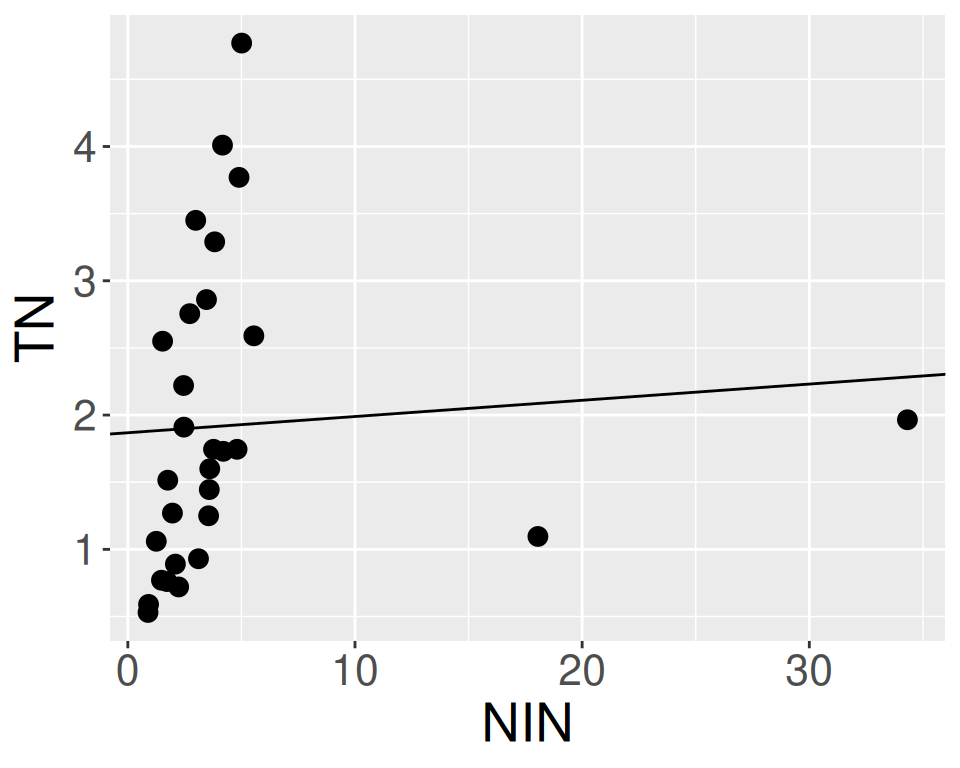

```r
ggplot(lake, aes(x = NIN, y = TN)) +
  geom_point(size = 3) +
  geom_abline(intercept = b0, slope = b1) +
  theme(text = element_text(size = 20))
```

# Question 4

Using the model from question 2, create a scatter plot of the residuals.

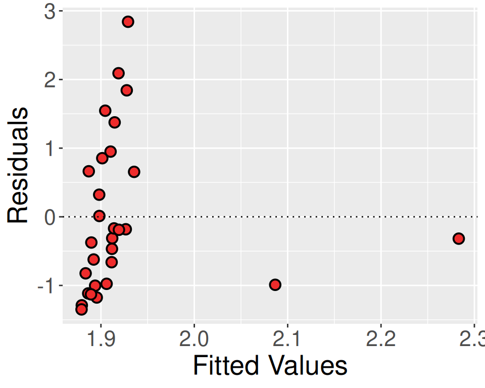

```r
# Predicted/Fitted Values
lake$y_hat <- b0 + b1 * lake$NIN

# Residuals
lake$resid <- lake$TN - lake$y_hat

# Residual Plot
ggplot(lake, aes(x = y_hat, y = resid)) +
  geom_point(
    shape = 21,
    stroke = 1,
    fill = "firebrick2",
    size = 3
  ) +
  geom_hline(yintercept = 0, linetype = 3) +
  ylab("Residuals") + xlab("Fitted Values") +
  theme(text = element_text(size = 20))
```

- Note that the values from the NIN column could have also been plotted on the x-axis.

# Question 5

Using the model from question 2, create a Q-Q plot of the residuals and answer the question “are the residuals normally distributed?”

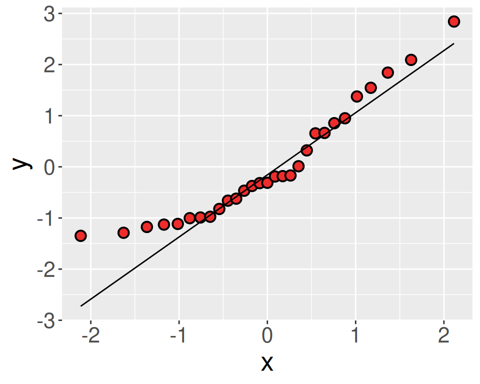

```r
# Q-Q Plot
ggplot(lake, aes(sample = resid)) +
  stat_qq(
    shape = 21,
    stroke = 1,
    fill = "firebrick2",
    size = 3
  ) +
  stat_qq_line() +
  theme(text = element_text(size = 20))
```

The residuals show a systematic departure from a straight line at the lower end and are best considered not normally distributed.

# Question 6

Assume the data satisfies all the necessary assumptions. Assess whether the slope is significantly different from 0, reporting the test-statistic, p-value, and confidence interval. What do you conclude?

- Use of `lm()` is not permitted.

```r
# Squared standard error of the residuals
res_sq_se <- (sum(lake$resid^2) / (n - 2))

# Sum of squared deviations
ss_x <- sum((lake$NIN - mean(lake$NIN))^2)

# Slope standard error
s_b1 <- sqrt(res_sq_se / ss_x)

# Degrees of freedom
P <- 1
df <- n - P - 1

# Test H0: b1 = 0
t_stat <- (b1 - 0) / s_b1

p <- pt(t_stat, df = df, lower.tail = FALSE) * 2

# T_crit
alpha <- 0.05
t_crit <- abs(qt(alpha / 2, df = df))

# 95% CI on Slope
lower <- b1 - t_crit * s_b1
upper <- b1 + t_crit * s_b1
```

```
## T = 0.3639
```

```
## df = 27
```

```
## p = 0.7188
```

```
## 95% CI: [-0.0561, 0.0802]
```

We fail to reject the hypothesis that the slope is equal to 0.

# Question 7

Use the MAD-Median rule to detect potential outliers. List the outliers it finds.

You are allowed to use `mad()`.

```r
lake$out <- abs(lake$NIN - median(lake$NIN)) / mad(lake$NIN) > 2.24

lake |>
  filter(out == TRUE) |>
  select(NIN, TN, TW)
```

```
## # A tibble: 2 × 3
##     NIN    TN    TW
##   <dbl> <dbl> <dbl>
## 1 18.05 1.096 2.899
## 2 34.32 1.965 1.499
```

# Question 8

Remove the outliers flagged by the MAD-median rule, re-calculate your model, and state its formula.

You are allowed to use `lm()` for this and the remaining questions.

```r
lake_cln <- lake |>
  filter(out == FALSE) |>
  select(NIN, TN, TW)

model_cln <- lm(TN ~ NIN, data = lake_cln)

# Intercept
round(model_cln$coefficients[1], 4)
```

```
## (Intercept)
##      0.2867
```

```r
# Slope
round(model_cln$coefficients[2], 4)
```

```
##   NIN
## 0.562
```

**Formula:**

$\hat{y} = 0.2867 + 0.562 \cdot x$

# Question 9

Re-plot the data with the outliers removed and include the new and previous model’s regression lines. Make the new regression line dashed and the old solid.

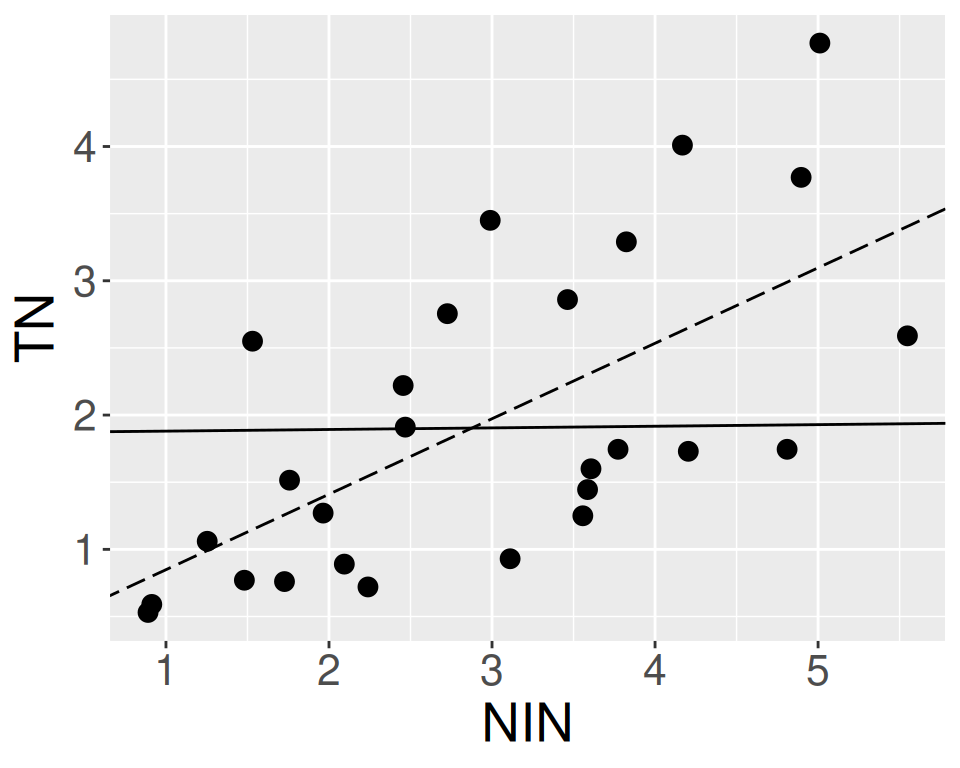

```r
ggplot(lake_cln, aes(x = NIN, y = TN)) +
  geom_point(size = 3) +
  geom_abline(
    intercept = model_cln$coefficients[1],
    slope = model_cln$coefficients[2],
    linetype = 5
  ) +
  geom_abline(intercept = b0, slope = b1) +

  theme(text = element_text(size = 20))
```

# Question 10

Create a scatter plot and a Q-Q plot of the residuals for the data that had outliers removed. Would you feel comfortable running a t-test to evaluate the slope of this data? Why or why not?

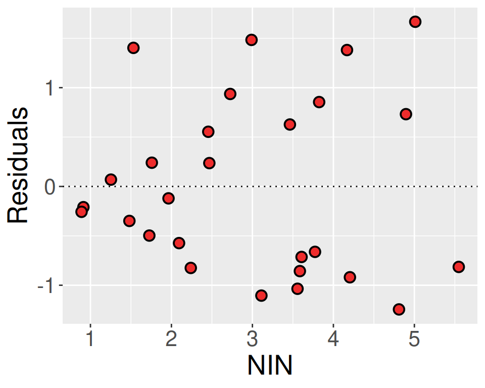

```r
# Scatterplot
ggplot(lake_cln, aes(x = NIN, y = model_cln$residuals)) +
  geom_point(
    shape = 21,
    stroke = 1,
    fill = "firebrick2",
    size = 3
  ) +
  geom_hline(yintercept = 0, linetype = 3) +
  ylab("Residuals") +
  theme(text = element_text(size = 20))
```

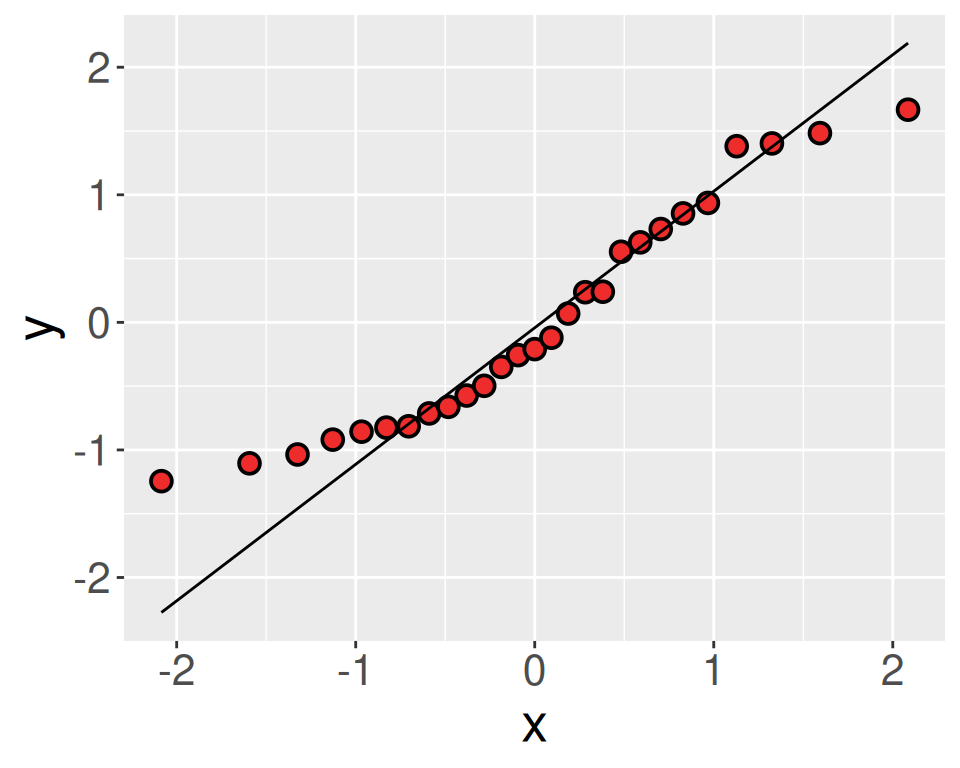

```r
# Q-Q Plot
ggplot(lake_cln, aes(sample = model_cln$residuals)) +
  stat_qq(
    shape = 21,
    stroke = 1,
    fill = "firebrick2",
    size = 3
  ) +
  stat_qq_line() +
  theme(text = element_text(size = 20))
```

There is no clear suggestion of heteroscedasticity in the residuals. However, the Q-Q plot shows departures from normality in the lower tail. I would not feel comfortable trusting the test and would probably look for robust alternatives.